# Spatial Analysis and Geocomputation

Sila

## Assignemnt 2

- In this assignment please follow the instructions step by step.
- Produce the maps, tables and graphs as asked.
- There are 13 tasks in this assignment. Please format your submission so each point consists of the code and output produced as well as the answers to the questions about the maps and graphs (WRITTEN PART). As the headings you can use the numbered tasks (1. make a choropleth map …)
- Answers to the WRITTEN PARTS do not have to be long: 2 - 5 sentences.
- Your assignment should be submitted through Canvas as a pdf/html.
- Make sure that you comment your code.

Data for for this assignment will be available to download from canvas. (Data lab2) For your convenience you can load all the libraries required for this assignment at the beginning of your Rmarkdown.

HINT: if you add eval=FALSE into your `{r}` chunks it will not run your code. Make sure you delete them.

```r
setwd("C:\\Users\\ksil287\\Dropbox\\Auckland\\Teaching\\sem 1 2022\\771\\Assignment 2  Lab 3 and 4")
```

## Part 1

You are provided with the 2001 census data by ethnicity of the Auckland isthmus, one at the meshblock level (akCity_mb01_ethnic) and another the census area unit (CAU) (akCity_CAU01_ethnic) level. They are saved in the files on canvas.

### 1. Make a choropleth map of Percentage of Asian Population per meshblock (tmap or others).

- use library **library(sf)** to load *akCity_mb01_ethnic* shapefile as *“Ethnicity_mesh”* (you can name this dataset as you wish).

```r
library(sf)
Ethnicity_mesh<-st_read("./Data/akCity_mb01_ethnic.shp")
```

- I created for you a variable Percentage of Asian population and it is saved as:*pro_Asian* and is saved as values from 0 to 1 values so make sure you change it to percentage. Your data may not have projection - if that happens you can specify the projection in tmap as NULL.
- create a 5-class (quantile or equal interval) choropleth map showing percentage of Asian population. Remember about map title, north arrow, legend etc.

**WRITTEN PART STARTS**

- *What spatial pattern can you observe (e.g., which areas have the highest concentration of Asian population? Where is the lowest concentration)?*

**WRITTEN PART ENDS**

### 2. Make a choropleth map of Percentage of Asian Population (Asian_prop) per Census Area Unit.

- use library **library(sf)** to load *akCity_CAU01_ethnic* shapefile as *“Ethnicity”* (you can name this dataset as you wish).
- create a 5-class choropleth map showing percentage of Asian population. Remember about map title, north arrow, legend etc.

```r
library(tmap)
library(sf)          # classes and functions for vector data

# load geographic data

Ethnicity2<-read_sf("./Data/akCity_CAU01_ethnic.shp")

# continue to make your map here
```

**WRITTEN PART STARTS**

**WRITTEN PART ENDS**

### 3. Plot two choropleth maps next to each other and comment on the patterns and possible differences/similarities:

- plot the two choropleth maps next to each other. In order to do it use one of the commands listed below. In this example I use only the loaded dataset. I want you to load the ready choropleth maps. Look at the commented part of the code to find out how to do it in tmap.

```r
#If you are using ordinary plots you can use the following commands:
par(mfrow=c(1,2))
plot(st_geometry(Ethnicity2))
plot(st_geometry(Ethnicity_mesh))

# What happens if you change mfrow=c(2,1)?

# If you are using tmap - look into tmap_arrange(map1, map2, ncol=1,nrow=2)
```

**WRITTEN PART**

- *Compare the two choropleth maps you have produced above, paying particular attention to the locations of extreme values, especially the lowest values. What change has happened to the location/pattern of the highest values? Can you relate it to MAUP?*

**WRITTEN PART ENDS**

### 4. Aggregate the meshblock data by merging adjacent blocks.

- We want to change zoning of our data.

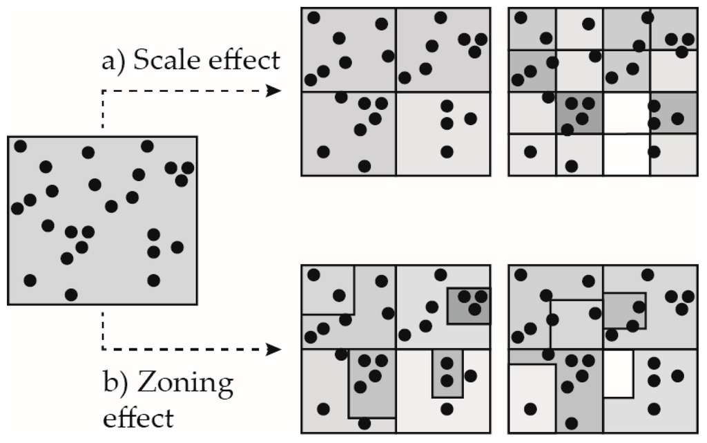

Fig. A short reminder what zoning is about

- First we will cluster data using k-means algorithm - an example of centroid-based clustering.

*Clustering is an unsupervised learning technique. It is the task of grouping together a set of objects in a way that objects in the same cluster are more similar to each other than to objects in other clusters. Similarity is an amount that reflects the strength of relationship between two data objects. Clustering is mainly used for exploratory data mining. It is used in many fields such as machine learning, pattern recognition, image analysis, information retrieval, bio-informatics, data compression, and computer graphics.*

*VIDEO TO WATCH*

To understand k-means clustering please watch the video and if you need to look through the attached document:

- https://www.youtube.com/watch?v=4b5d3muPQmA
- https://rpubs.com/riazakhan94/kmeans
- Our data have *“Ethnicity_mesh CNTRD_X”,“Ethnicity_mesh CNTRD_Y”* variables which represent coordinates of the meshblocks’ centroids and these will be used as an input into the clustering.
- I chose to cluster the data into 100 clusters (groupings) from the initial 2990 meshblocks in the Auckland area.
- to check the number of meshblocks you can use:

```r
#Numbr of meshblocks
length(Ethnicity_mesh$geometry)
```

- In order to cluster your data use the following command. Please do it step by step to understand what is being done:

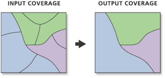

Fig. This is what “dissolve” does

```r
#using kmeans clustering to create 100 clusters of ethnicity for Auckland and adding the kmeans cluster column to the ethnicity_mesh dataframe
km <- kmeans(cbind(Ethnicity_mesh$CNTRD_X,Ethnicity_mesh$CNTRD_Y), centers = 100)


km2 <- kmeans(cbind(Ethnicity_mesh$CNTRD_X,Ethnicity_mesh$CNTRD_Y), centers = 100,iter.max = 35,nstart = 20) #iter.max set to 35 maximum iterations allowed, if centers is a number 20 random sets should be chosen using nstart


# you can plot the results of km and km2 and see the differences.
par(mfrow=c(1,2))
plot(Ethnicity_mesh$CNTRD_X,Ethnicity_mesh$CNTRD_Y,col=km$cluster,pch=20)
plot(Ethnicity_mesh$CNTRD_X,Ethnicity_mesh$CNTRD_Y,col=km2$cluster,pch=20)


# next you will need to assign the created clusters back to the main dataset. I used km to do so:


Ethnicity_mesh$Cluster<-as.factor(km$cluster)

## by  doing so we have added clusters (100 different ones) to our meshblock dataset. In order to see it on a map we need to dissolve our meshblocks into new geometries
```

```r
require("rgeos")
require("dplyr")

#dissolve meshblocks by type of Cluster

Ethnicity_new_clusters <- aggregate(Ethnicity_mesh, by = list(x=Ethnicity_mesh$Cluster),
                                    FUN=mean)



## just use the Ethnicity_new_clusters$pro_Asian to make a map.
```

### 5. Produce another choropleth map of the dissolved field using the same settings as you did before.

**WRITTEN PART STARTS**

- *Comment on the spatial pattern revealed. Comment on the effect of MAUP*

**WRITTEN PART ENDS**

## Part 3:

### 6. A bit of instructions: Getting Started with Spatstat

- First, load up the spatstat library:

```r
library(spatstat)
```

- Type data() to see a list of all the available datasets, one of which is called lansing, a point dataset of trees in Lansing, Michigan. To find more about it, type:

```r
data()
lansing
```

- The best way of visualising the dataset is to plot it- plot one by one to see what happens! Of course you can use fancy tmap package to visualise it in a nice and more professional way but sometimes we just want to quickly have a look at what data shows and using basic plots is really helpful.

```r
plot(lansing)
plot(split(lansing))
plot(density(split(lansing)))
```

### Spatial Point Processes

A few *random point patterns* can be generated using built-in functions that start with ‘r’ in R. The simplest type of spatial point process is ‘CSR’ or more properly the Poisson process. Complete spatial randomness describes a point process whereby point events occur within a given study area in a completely random fashion:

```r
plot(rpoispp(100))
```

It is based on a Poisson process with intensity 100. This expression works perfectly well except that its long name has to be repeated every time it is used. This can be simplified by assigning it to a short variable such as x.

```r
x = rpoispp(100)
plot(x)
```

More informative displays can be produced using:

```r
plot(density(x))
contour(density(x), add=T)
plot(x, add=T)
```

Other types of point process include rMatermII, and rMatClust. Run the following two commands:

```r
plot(rMaternII(100, 0.1))
plot(rMatClust(100, 0.05, 5))
```

**WRITTEN PART STARTS**

- *What can you characterize the point process generated by each of them? If you are not so sure, type ? “point_process_name”” to find the answer.*

**WRITTEN PART ENDS**

### 7. Identification of Kauri Tree Patterns

Data needed for this part are stored in the text file SpeciesMap.txt that contains point data of tree species, one of which is kauri (agathis australis or AGAU). The data can be read into rawdata (or whatever name you prefer) using the following command:

```r
## remember to change the directory
rawdata = read.table("./Data/SpeciesMap.txt", header=T, sep="\t")
```

_ To inspect the data, enter ‘rawdata’.

**WRITTEN PART STARTS**

*What is the spatial reference system used, local or global? Why do you think so?*

**WRITTEN PART ENDS**

- To inspect a single variable, type

```r
rawdata$Species
```

- Where the dollar sign indicates that we are referring to a particular attribute of the dataset. A map of the data can be made using plot.
- Remember that dollar works for data.frames and will not work for big spatial data.frames. In order to look into what is in the spatial.data.frame we will use *@_ like that:* ’Ethnicity_mesh@data$Cluster’_

```r
plot(rawdata$x, rawdata$y)
```

Even though data can look like point patterns we need to inform R that has a propoer format. A point pattern can be generated using the ppp (point pattern process) function:

```r
pts <- ppp(rawdata$x, rawdata$y, marks=rawdata$Species, xrange=c(0,40), yrange=c(0,50))
```

Data on the kauri species can be extracted using its code:

```r
kauri <- pts[rawdata$Species=='AGAU']
```

### 8. Produce a density and a contour map of kauri distribution using the functions you learened in Section “Spatial Point Processes” or the seperate tutorial linked to canvas page. You can use any library you wish.

- insert the maps into your answer.

**WRITTEN PART STARTS**

*Based on these two maps, briefly describe the point pattern shown. Is it spatially random, even or clustered? Why?*

**WRITTEN PART ENDS**

### 9a Distance-based Pattern Analyses of Kauri Trees

Gest,Fest, Kest, and Lest are R functions able to perform standard distance-based point pattern analysis. The nature of the K-function makes it difficult to graphically discern differences between $L_{theo}$ and $\hat L$ at lower $d$ values. A workaround is to transform the data which gives us the estimated L-function.

You can find more information about transformations between K and L functions below: http://personal.colby.edu/personal/m/mgimond/Spatial/K_and_L_functions.html

- Run Lest, Kest, Gest and Fest on kauri:

```r
l = Gest(kauri)
k = Kest(kauri)
m = Lest(kauri)
n= Fest(kauri)
```

- use plot() to examine each of the analysis results. It must be noted that the results themselves alone do not make much sense if not assessed in relation to a point process model, such as the theoretical value shown in the plots. A better approach is to compare the actual pattern to a collection of simulated results using the envelope function:

```r
Kenv = envelope(kauri, Kest, nsim=99, rank=1)
plot(Kenv)
```

This will produce a plot showing the limits of the envelope of simulated patterns (99 in this case, with the first highest and lowest cases, as specified by rank=1 plotted as hi and lo). Interpretation of the plot is the primary means of assessing the degree of clustering (aggregation) or evenness in the pattern.

**WRITTEN PART STARTS**

- *Attach the plots to your answer. Based on these plots, what conclusions can you draw about the patterns?*

**WRITTEN PART ENDS**

### 9b Distance-based Pattern Analyses of Kauri Trees

Another method of point pattern analysis is the quadrat counting approach using quadratcount:

```r
q = quadratcount(kauri)
plot(kauri)
plot(q, add=T)
quadrat.test(kauri)
```

**WRITTEN PART STARTS**

- *What is the outcome of the quandrat test for kauri trees (insert the results to this answer)?*

**WRITTEN PART ENDS**

### Part 4:

### Spatial Interpolation

You can use the code provided by Gimond in their Intro to GIS tutorial: https://mgimond.github.io/Spatial/interpolation-in-r.html

Read in two shapefiles: Park_boundary and POints_Park_DOmain. The first file is a border of the Auckland Domain whereas the second file is a file with sample locations with values of relative humidity, temperature and wind speed that were collected in the park in the last couple of years.

### 10-12. Run three different types of spatial interpolation methods (Voronoi-based, Kriging and IDW) for all three attributes in your dataset.

Hint: Use autofitVariogram in automap package to get psill, model and range values for all 3 variables autofitVariogram(Humidity~ X + Y,points_domain)

### 13. Generate the variance and confidence interval maps for Kriging interpolations for all three attributes.

**WRITTEN PART STARTS**

- *What are the differences between these different interpolation methods?*

**WRITTEN PART ENDS**